# Okinawa guppies

Sasha Mikheyev

10/30/2018

# Site structure

```r
mds <- read_table("data/all.mds") %>% separate(FID, c("site", "ind"), extra = "merge") %>% select(site, id = IID, C1, C2)
```

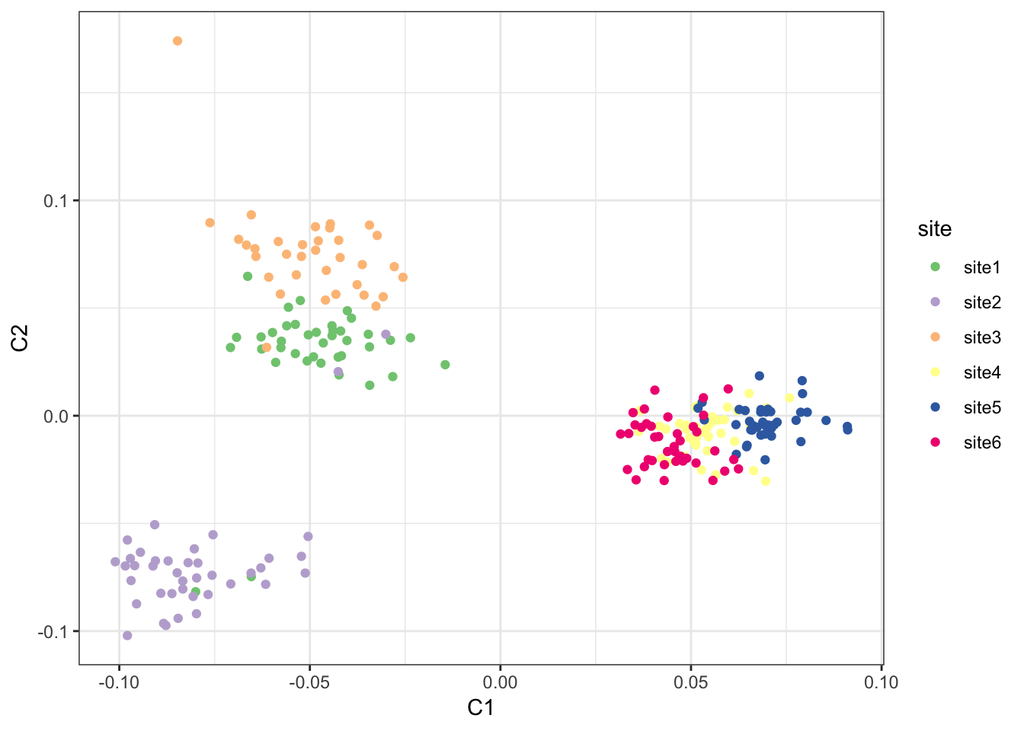

```r
ggplot(mds, aes(C1, C2, color=site)) + geom_point() + scale_color_brewer(type='qual')+theme_bw()
```

Looks like there are some individuals may have been switched, and we’ll drop them just in case, though the full analysis is presented below.

# Read phenotypic data from VCFtools

filtered using vcftools `--mac 10 --max-missing 0.5 --minQ 20 --minDP 6`

```r
pheno <- read_tsv("data/guppy pheno.tsv", col_types = cols()) %>% mutate(orange=rowMeans(cbind(L_Orangearea, R_Orangearea), na.rm=T), site = factor(Site)) %>% select(site, Label, orange, TopBottom) %>% left_join(read_csv("data/geno2pheno.csv", col_types = cols()), by=c("Label" = "pheno")) %>% left_join(read_tsv("data/out.het", col_types = cols()) %>% mutate(het = 1 - `O(HOM)`/ N_SITES) %>% select(gen = INDV, het, F, nsites = N_SITES)) %>% na.omit()
```

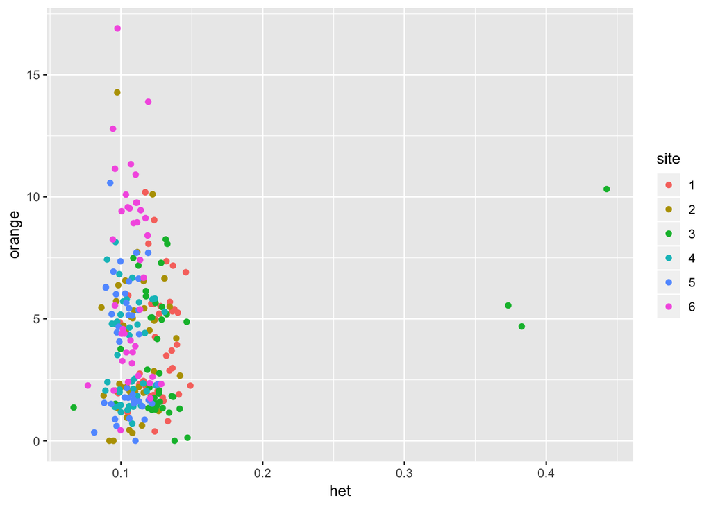

```r
ggplot(pheno, aes(het, orange, color=site))+geom_point()
```

```r
model.sameSlopes <- lmer(sqrt(orange) ~ het + (1|site), data = pheno)
model.sepSlopes <- lmer(sqrt(orange) ~ het + (het|site), data = pheno)
anova(model.sepSlopes,model.sameSlopes)
```

```
## refitting model(s) with ML (instead of REML)
```

```
## Data: pheno
## Models:
## model.sameSlopes: sqrt(orange) ~ het + (1 | site)
## model.sepSlopes: sqrt(orange) ~ het + (het | site)
##                  Df    AIC    BIC  logLik deviance  Chisq Chi Df
## model.sameSlopes  4 530.06 543.98 -261.03   522.06
## model.sepSlopes   6 533.63 554.52 -260.82   521.63 0.4236      2
##                  Pr(>Chisq)
## model.sameSlopes
## model.sepSlopes      0.8091
```

```r
summary(model.sameSlopes)
```

```
## Linear mixed model fit by REML. t-tests use Satterthwaite's method [
## lmerModLmerTest]
## Formula: sqrt(orange) ~ het + (1 | site)
##    Data: pheno
##
## REML criterion at convergence: 522.1
##
## Scaled residuals:
##     Min      1Q  Median      3Q     Max
## -2.6178 -0.7323 -0.1014  0.7762  2.8281
##
## Random effects:
##  Groups   Name        Variance Std.Dev.
##  site     (Intercept) 0.06597  0.2568
##  Residual             0.49661  0.7047
## Number of obs: 240, groups:  site, 6
##
## Fixed effects:
##             Estimate Std. Error       df t value Pr(>|t|)
## (Intercept)   1.6094     0.1987  37.2599   8.099 9.77e-10 ***
## het           2.7588     1.3995 236.6523   1.971   0.0499 *
## ---
## Signif. codes:  0 '***' 0.001 '**' 0.01 '*' 0.05 '.' 0.1 ' ' 1
##
## Correlation of Fixed Effects:
##     (Intr)
## het -0.818
```

Using a basic mixed model approach, there is marginal significance for the effect of heterozygosity. Given that there is no support for a model with separate slopes, we’ll focus on the random intercept mixed model.

### Applying within-group centering

```r
phenoCentered <- pheno %>% group_by(site) %>% transmute(het = het, sqrtOrange = sqrt(orange), meanSite = mean(het), withinSite = het - meanSite)  %>% ungroup()

model.CenteredSameSlopes2 <- lmer(sqrtOrange ~ withinSite + meanSite + (1|site), data = phenoCentered)
summary(model.CenteredSameSlopes2)
```

```
## Linear mixed model fit by REML. t-tests use Satterthwaite's method [
## lmerModLmerTest]
## Formula: sqrtOrange ~ withinSite + meanSite + (1 | site)
##    Data: phenoCentered
##
## REML criterion at convergence: 515.3
##
## Scaled residuals:
##      Min       1Q   Median       3Q      Max
## -2.63755 -0.73556 -0.09651  0.75648  2.82301
##
## Random effects:
##  Groups   Name        Variance Std.Dev.
##  site     (Intercept) 0.0688   0.2623
##  Residual             0.4966   0.7047
## Number of obs: 240, groups:  site, 6
##
## Fixed effects:
##             Estimate Std. Error       df t value Pr(>|t|)
## (Intercept)   2.4390     0.9375   4.0000   2.602   0.0599 .
## withinSite    2.9922     1.4222 233.0000   2.104   0.0365 *
## meanSite     -4.3833     8.0083   4.0000  -0.547   0.6132
## ---
## Signif. codes:  0 '***' 0.001 '**' 0.01 '*' 0.05 '.' 0.1 ' ' 1
##
## Correlation of Fixed Effects:
##            (Intr) wthnSt
## withinSite  0.000
## meanSite   -0.992  0.000
```

```r
model.CenteredSameSlopes3 <- lmer(sqrtOrange ~ het + meanSite + (1|site), data = phenoCentered)
summary(model.CenteredSameSlopes3)
```

```
## Linear mixed model fit by REML. t-tests use Satterthwaite's method [
## lmerModLmerTest]
## Formula: sqrtOrange ~ het + meanSite + (1 | site)
##    Data: phenoCentered
##
## REML criterion at convergence: 515.3
##
## Scaled residuals:
##      Min       1Q   Median       3Q      Max
## -2.63755 -0.73556 -0.09651  0.75648  2.82301
##
## Random effects:
##  Groups   Name        Variance Std.Dev.
##  site     (Intercept) 0.0688   0.2623
##  Residual             0.4966   0.7047
## Number of obs: 240, groups:  site, 6
##
## Fixed effects:
##             Estimate Std. Error       df t value Pr(>|t|)
## (Intercept)   2.4390     0.9375   4.0000   2.602   0.0599 .
## het           2.9922     1.4222 233.0000   2.104   0.0365 *
## meanSite     -7.3755     8.1336   4.2562  -0.907   0.4129
## ---
## Signif. codes:  0 '***' 0.001 '**' 0.01 '*' 0.05 '.' 0.1 ' ' 1
##
## Correlation of Fixed Effects:
##          (Intr) het
## het       0.000
## meanSite -0.977 -0.175
```

```r
anova(model.CenteredSameSlopes2, model.CenteredSameSlopes3)
```

```
## refitting model(s) with ML (instead of REML)
```

```
## Data: phenoCentered
## Models:
## model.CenteredSameSlopes2: sqrtOrange ~ withinSite + meanSite + (1 | site)
## model.CenteredSameSlopes3: sqrtOrange ~ het + meanSite + (1 | site)
##                           Df    AIC    BIC  logLik deviance Chisq Chi Df
## model.CenteredSameSlopes2  5 530.94 548.35 -260.47   520.94
## model.CenteredSameSlopes3  5 530.94 548.35 -260.47   520.94     0      0
##                           Pr(>Chisq)
## model.CenteredSameSlopes2
## model.CenteredSameSlopes3          1
```

Tha above two models are equivalent ways of writing applying the same within-subject centering procedure, corresponding to equations 2 and 3 of van de Pol and Wright (2009).

We try a separate slopes model next.

```r
 model.CenteredDiffSlopes <- lmer(sqrtOrange ~  withinSite + meanSite + (withinSite|site), data = phenoCentered)

anova(model.CenteredSameSlopes2, model.CenteredDiffSlopes)
```

```
## refitting model(s) with ML (instead of REML)
```

```
## Data: phenoCentered
## Models:
## model.CenteredSameSlopes2: sqrtOrange ~ withinSite + meanSite + (1 | site)
## model.CenteredDiffSlopes: sqrtOrange ~ withinSite + meanSite + (withinSite | site)
##                           Df    AIC    BIC  logLik deviance  Chisq Chi Df
## model.CenteredSameSlopes2  5 530.94 548.35 -260.47   520.94
## model.CenteredDiffSlopes   7 534.92 559.28 -260.46   520.92 0.0256      2
##                           Pr(>Chisq)
## model.CenteredSameSlopes2
## model.CenteredDiffSlopes      0.9873
```

The separate slopes model is not justified. Within-site centering gives stronger significance.

```r
model.CenteredSameSlopes3@beta[1]^2
```

```
## [1] 5.948706
```

```r
confint(model.CenteredSameSlopes3, "het")^2
```

```
## Computing profile confidence intervals ...
```

```
##          2.5 %   97.5 %
## het 0.03969765 33.46705
```

## Read genotypes

We calculate the GRM and get it ready for `sommer`/`brms` analysis. First we see if including a GRM actually helps our analysis.

```r
indvs <- read_tsv("data/out.012.indv", col_names = c("gen")) %>% left_join(read_csv("data/geno2pheno.csv", col_types = cols())) # read data
pheno <- left_join(indvs, pheno) # re-order pheno data frame to match genotypes
pos <- read_tsv("data/out.012.pos", col_names = c("chrom", "pos"), col_types = "cn") %>% mutate(marker = paste(chrom, pos, sep = "_"))
gen <- cbind(indvs, read_tsv("data/out.012", col_names = F) - 1 )
G <- A.mat(gen %>% select(-c(gen, pheno)))
colnames(G) <- gen$gen
rownames(G) <- gen$gen

siteColors <- data.frame(site = gsub("(site\\d).*", "\\1", rownames(G))) %>% left_join(data.frame(site = paste0("site",1:6), color = scales::brewer_pal(type="qual")(6)), stringsAsFactors = F)
```

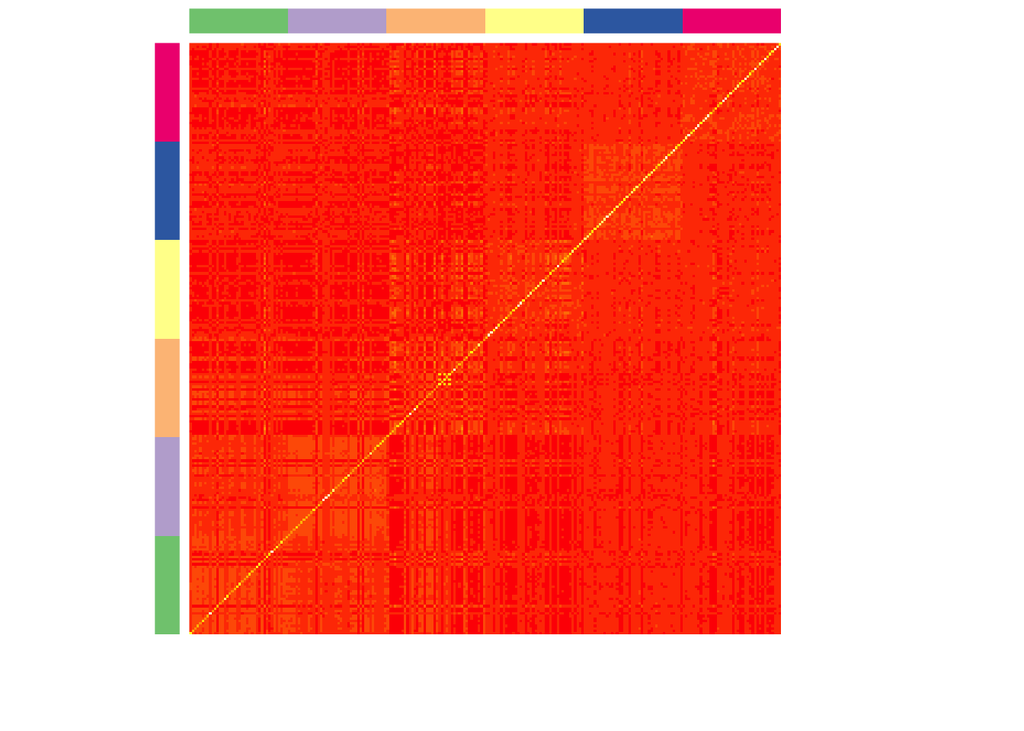

```r
heatmap(G, Rowv=NA, Colv=NA, ColSideColors=as.character(siteColors$color), RowSideColors=as.character(siteColors$color), labRow = NA, labCol = NA)
```

```r
# Add a small amount to the diagonal so G is invertable
diag(G) <- diag(G)+0.001
#Need to invert G for the mixed model equations
orangeModel.sommer <- mmer2(sqrtOrange~1+het,
                            random=~g(gen) + site,
                            rcov=~units,
                            G=list(gen=G),
                            tolpar = 1e-02,
                            iters = 20,
                            silent=T,
                            data=pheno %>% mutate(sqrtOrange = sqrt(orange)))
```

```
## Version out of date. Please update sommer to the newest version using:
## install.packages('sommer') in a new session
```

```r
orangeModel.sommer.noGRM <- mmer2(sqrtOrange~1,
                            random=~site,
                            rcov=~units,
                            tolpar = 1e-02,
                            iters = 20,
                            silent=T,
                            data=pheno %>% mutate(sqrtOrange = sqrt(orange)))
```

```
## Version out of date. Please update sommer to the newest version using:
## install.packages('sommer') in a new session
```

```r
anova(orangeModel.sommer.noGRM, orangeModel.sommer)
```

```
## Likelihood ratio test for mixed models
## ==============================================================
##      Df      AIC      BIC     loLik   Chisq ChiDf  PrChisq
## mod2  5 226.5032 233.4645 -111.2516
## mod1  3 227.8610 231.3417 -112.9305 3.35784     2 0.18658
## ==============================================================
## Signif. codes:  0 '***' 0.001 '**' 0.01 '*' 0.05 '.' 0.1 ' ' 1
```

Adding a GRM term does not improve model fit for the mixed model.

## Looking only at chromosome 12, the location of the sex determination locus

```r
G12 <- A.mat(gen[,which(pos$chrom==12)+2])
diag(G12) <- diag(G12)+0.001
colnames(G12) <- gen$gen
rownames(G12) <- gen$gen

orangeModel12.sommer <- mmer2(sqrtOrange~1+het,
                            random=~g(gen) + site,
                            rcov=~units,
                            G=list(gen=G12),
                            iters = 20,
                            tolpar = 1e-02,
                            silent=T,
                            data=pheno %>% mutate(sqrtOrange = sqrt(orange)))
```

```
## Version out of date. Please update sommer to the newest version using:
## install.packages('sommer') in a new session
```

```r
summary(orangeModel12.sommer)
```

```
## ======================================================
##       Multivariate Linear Mixed Model fit by REML
## ********************  sommer 3.5  ********************
## ======================================================
##          logLik      AIC      BIC Method Converge
## Value -110.9433 225.8866 232.8479    MNR     TRUE
## ======================================================
## Variance-Covariance components:
##                               VarComp VarCompSE Zratio
## g(gen).sqrtOrange-sqrtOrange 0.001893  0.005963 0.3174
## site.sqrtOrange-sqrtOrange   0.064442  0.049455 1.3030
## units.sqrtOrange-sqrtOrange  0.490951  0.049151 9.9886
## ======================================================
## Fixed effects:
##
## $sqrtOrange
##             Estimate Std. Error  t value
## (Intercept) 1.606978  0.2008375 8.001385
## het         2.779454  1.4289149 1.945150
##
## ======================================================
## Groups and observations:
##        Observ Groups
## g(gen)    240    240
## site      240      6
## ======================================================
## Use the '$' sign to access results and parameters
```

Nothing really unusual on chr12.

## Bayesian solution

```r
model.brms.full <- brm(orange ~ het + (1|site) + (1|gen),
                cov_ranef = list(gen=G),
                control = list(adapt_delta = 0.99),
                data = pheno,
                cores = 2)
model.brms.noGRM <- brm(orange ~ het + (1|site) ,
                control = list(adapt_delta = 0.99),
                data = pheno,
                cores = 2)
```

```r
waic(model.brms.full, model.brms.noGRM)
```

```
##                                       WAIC    SE
## model.brms.full                    1176.64 24.28
## model.brms.noGRM                   1183.88 25.44
## model.brms.full - model.brms.noGRM   -7.24  1.96
```

```r
summary(model.brms.full)
```

```
##  Family: gaussian
##   Links: mu = identity; sigma = identity
## Formula: orange ~ het + (1 | site) + (1 | gen)
##    Data: pheno (Number of observations: 240)
## Samples: 4 chains, each with iter = 2000; warmup = 1000; thin = 1;
##          total post-warmup samples = 4000
##
## Group-Level Effects:
## ~gen (Number of levels: 240)
##               Estimate Est.Error l-95% CI u-95% CI Eff.Sample Rhat
## sd(Intercept)     0.50      0.36     0.01     1.27        197 1.01
##
## ~site (Number of levels: 6)
##               Estimate Est.Error l-95% CI u-95% CI Eff.Sample Rhat
## sd(Intercept)     1.61      0.83     0.66     3.66       1316 1.00
##
## Population-Level Effects:
##           Estimate Est.Error l-95% CI u-95% CI Eff.Sample Rhat
## Intercept     2.82      1.05     0.72     4.86       1534 1.00
## het          12.61      6.66     0.42    26.64        917 1.00
##
## Family Specific Parameters:
##       Estimate Est.Error l-95% CI u-95% CI Eff.Sample Rhat
## sigma     2.62      0.27     1.95     3.03        176 1.01
##
## Samples were drawn using sampling(NUTS). For each parameter, Eff.Sample
## is a crude measure of effective sample size, and Rhat is the potential
## scale reduction factor on split chains (at convergence, Rhat = 1).
```

For the Bayesian fit, you do have a better model with with a GRM, and a significan effect of heterozygosite on organge.

# GWAS

Are there loci associated with the orange phenotype?

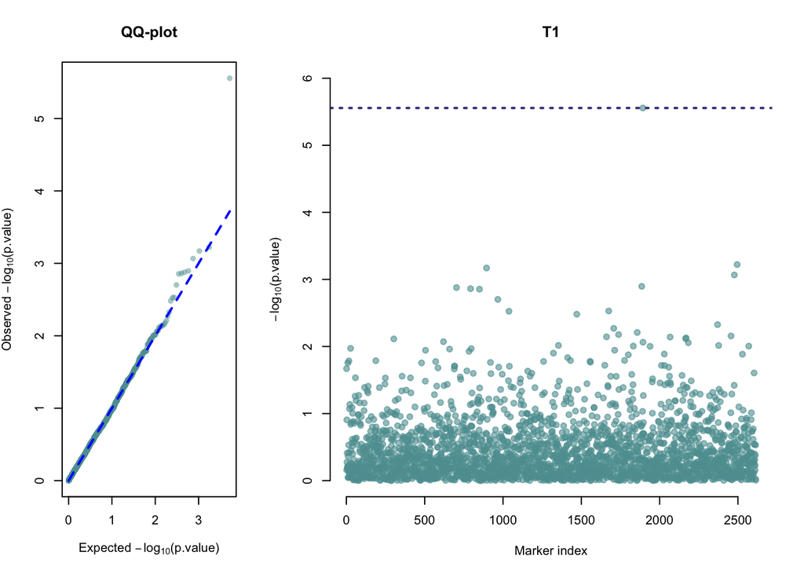

```r
Za <- diag(dim(pheno)[1]) # create mapping between phenotype and genotype
ETA.A <- list(add=list(Z=Za,K=G))
ans <- GWAS(Y=pheno[,c("orange")], Z=ETA.A, M=gen %>% select(-c(gen, pheno)), silent=T)
```

```r
pos[which(ans$M.scores$score > ans$fdr),]
```

```
## # A tibble: 0 x 3
## # ... with 3 variables: chrom <chr>, pos <dbl>, marker <chr>
```

There are no significantly loci associated with orange coloration that we could detect.